# Model_jh4054

Joy Hsu

12/7/2018

### Load Main dataset

```r
cancer_reg = read_csv("./data/Cancer_Registry.csv") %>%
  janitor::clean_names() %>%
  dplyr::select(target_death_rate, everything()) %>%
  separate(geography, into = c("county", "state"), sep = ", ") %>%
  mutate(
    avg_deaths_per_year = as.numeric(avg_deaths_per_year),
    med_income = as.numeric(med_income),
    pop_est2015 = as.numeric(pop_est2015),
    county = str_replace(county, " ", "")) %>%
  dplyr::select(state, county, everything()) %>%
  arrange(target_death_rate, incidence_rate)
```

### 1. Remove Categorical and high proportion missing values

- Remove state and county - catergorical parameters related to observations
- Remove avg_ann_count and avg_deaths_per_year, since this data is already captured in mortality rate and incidence, weighted by county population.
- Remove variables with high percentage missing values:
  - pct_employed16_over - 152 missing. This variable has some collinearity with pct_unemployed16_over (R = -0.65), so we are not completely excluding information related to employment.
  - pct_some_col18_24 - 2285 missing. Over 2/3 missing values.
  - pct_private_coverage_alone - 609 missing. Since this variable has strong collinearity with pct_private_coverage (R = 0.93), so we are not excluding valuable information on insurance coverage

```r
# Examine missing values
# 3 variables with high missing: values pct_employed16_over (152), pct_some_col18_24 (2285), pct_private_coverage_alone (609)
skimr::skim(cancer_reg)
```

```
## Skim summary statistics
##  n obs: 3047
##  n variables: 35
##
## -- Variable type:character ----------------------------------------------------------------------------------------------------
##    variable missing complete    n min max empty n_unique
##  binned_inc       0     3047 3047  16  18     0       10
##      county       0     3047 3047   9  30     0     1819
##       state       0     3047 3047   4  20     0       51
##
## -- Variable type:numeric ------------------------------------------------------------------------------------------------------
##                    variable missing complete    n     mean        sd
##               avg_ann_count       0     3047 3047   606.34   1416.36
##         avg_deaths_per_year       0     3047 3047   185.97    504.13
##          avg_household_size       0     3047 3047     2.48      0.43
##                  birth_rate       0     3047 3047     5.64      1.99
##              incidence_rate       0     3047 3047   448.27     54.56
##                  med_income       0     3047 3047 47063.28  12040.09
##                  median_age       0     3047 3047    45.27     45.3
##           median_age_female       0     3047 3047    42.15      5.29
##             median_age_male       0     3047 3047    39.57      5.23
##                   pct_asian       0     3047 3047     1.25      2.61
##           pct_bach_deg18_24       0     3047 3047     6.16      4.53
##         pct_bach_deg25_over       0     3047 3047    13.28      5.39
##                   pct_black       0     3047 3047     9.11     14.53
##       pct_emp_priv_coverage       0     3047 3047    41.2       9.45
##         pct_employed16_over     152     2895 3047    54.15      8.32
##                 pct_hs18_24       0     3047 3047    35         9.07
##               pct_hs25_over       0     3047 3047    34.8       7.03
##      pct_married_households       0     3047 3047    51.24      6.57
##              pct_no_hs18_24       0     3047 3047    18.22      8.09
##              pct_other_race       0     3047 3047     1.98      3.52
##        pct_private_coverage       0     3047 3047    64.35     10.65
##  pct_private_coverage_alone     609     2438 3047    48.45     10.08
##         pct_public_coverage       0     3047 3047    36.25      7.84
##   pct_public_coverage_alone       0     3047 3047    19.24      6.11
##           pct_some_col18_24    2285      762 3047    40.98     11.12
##       pct_unemployed16_over       0     3047 3047     7.85      3.45
##                   pct_white       0     3047 3047    83.65     16.38
##             percent_married       0     3047 3047    51.77      6.9
```

[output cut: 22 more lines]

```
##     22.99     47.76    51.67    55.4      78.08 ▁▁▂▆▇▂▁▁
##      0        12.8     17.1     22.7      64.1  ▂▇▇▃▁▁▁▁
##      0         0.3      0.83     2.18     41.93 ▇▁▁▁▁▁▁▁
##     22.3      57.2     65.1     72.1      92.3  ▁▁▂▅▇▇▅▁
##     15.7      41       48.7     55.6      78.9  ▁▁▅▇▇▅▂▁
##     11.2      30.9     36.3     41.55     65.1  ▁▂▅▇▇▃▁▁
##      2.6      14.85    18.8     23.1      46.6  ▁▃▇▇▃▁▁▁
##      7.1      34       40.4     46.4      79    ▁▁▅▇▅▂▁▁
##      0.4       5.5      7.6      9.7      29.4  ▂▇▇▂▁▁▁▁
##     10.2      77.3     90.06    95.45    100    ▁▁▁▁▁▂▃▇
##     23.1      47.75    52.4     56.4      72.5  ▁▁▁▅▇▇▂▁
##    827     11684    26643    68671     1e+07    ▇▁▁▁▁▁▁▁
##      3.2      12.15    15.9     20.4      47.4  ▂▇▇▅▂▁▁▁
##      0         0        0       83.65   9762.31 ▇▁▁▁▁▁▁▁
##     59.7     161.2    178.1    195.2     362.8  ▁▁▆▇▂▁▁▁
```

```r
# observe collinearity between pct_private_coverage and variable to exclude, pct_private_coverage_alone
cancer_reg %>%
  dplyr::select(target_death_rate, pct_private_coverage, pct_private_coverage_alone) %>% cor(x = ., use = "pairwise.complete.obs")
```

```
##                            target_death_rate pct_private_coverage
## target_death_rate                  1.0000000           -0.3860655
## pct_private_coverage              -0.3860655            1.0000000
## pct_private_coverage_alone        -0.3637037            0.9334958
##                            pct_private_coverage_alone
## target_death_rate                          -0.3637037
## pct_private_coverage                        0.9334958
## pct_private_coverage_alone                  1.0000000
```

```r
# observe collinearity between pct_unemployed16_over and variable to exclude, pct_employed16_over
cancer_reg %>%
  dplyr::select(target_death_rate, pct_unemployed16_over, pct_employed16_over) %>% cor(x = ., use = "pairwise.complete.obs")
```

```
##                       target_death_rate pct_unemployed16_over
## target_death_rate             1.0000000             0.3784124
## pct_unemployed16_over         0.3784124             1.0000000
## pct_employed16_over          -0.4120458            -0.6481142
##                       pct_employed16_over
## target_death_rate              -0.4120458
## pct_unemployed16_over          -0.6481142
## pct_employed16_over             1.0000000
```

```r
# remove variables with high missing values, county and state
cancer_reg_tidy = cancer_reg %>%
  dplyr::select(-pct_employed16_over, -pct_some_col18_24, -pct_private_coverage_alone, -county, -state, -avg_ann_count, -avg_deaths_per_year)
```

### 2. Remove Variables with high Collinearity

Other variables of consideration. * pct_white and pct_black has high CL (-0.83), but from a demographic standpoint, we may be interested in keeping both. * create pct_nonwhite as a proxy * discuss why pct_black and pct_white has such negative correlation in report

We are left with 21 variables

```r
# Examine collinearity between variables
cor_df = cancer_reg_tidy %>%
  dplyr::select(-binned_inc) %>%
  cor()

# remove collinear variables
# remove variables due to missing values
# remove variables due to collinearity
# create proxy variable pct_nonwhite
cancer_reg_tidy = cancer_reg %>%
  dplyr::select(
    -pct_employed16_over, -pct_some_col18_24, -pct_private_coverage_alone, -county, -state, -avg_ann_count, -avg_deaths_per_year) %>%
  dplyr::select(
    -median_age_female, -pct_emp_priv_coverage, -pct_public_coverage, -pct_private_coverage, -poverty_percent, -pct_hs25_over, -percent_married, -binned_inc) %>%
  mutate(pct_nonwhite = 1 - pct_white) %>%
  arrange(target_death_rate, incidence_rate)

skimr::skim(cancer_reg_tidy)
```

```
## Skim summary statistics
##  n obs: 3047
##  n variables: 21
##
## -- Variable type:numeric ------------------------------------------------------------------------------------------------------
##                   variable missing complete    n     mean        sd
##         avg_household_size       0     3047 3047     2.48      0.43
##                 birth_rate       0     3047 3047     5.64      1.99
##             incidence_rate       0     3047 3047   448.27     54.56
##                 med_income       0     3047 3047 47063.28  12040.09
##                 median_age       0     3047 3047    45.27     45.3
##            median_age_male       0     3047 3047    39.57      5.23
##                  pct_asian       0     3047 3047     1.25      2.61
##          pct_bach_deg18_24       0     3047 3047     6.16      4.53
##        pct_bach_deg25_over       0     3047 3047    13.28      5.39
##                  pct_black       0     3047 3047     9.11     14.53
##                pct_hs18_24       0     3047 3047    35         9.07
##     pct_married_households       0     3047 3047    51.24      6.57
##             pct_no_hs18_24       0     3047 3047    18.22      8.09
##               pct_nonwhite       0     3047 3047   -82.65     16.38
##             pct_other_race       0     3047 3047     1.98      3.52
##  pct_public_coverage_alone       0     3047 3047    19.24      6.11
##      pct_unemployed16_over       0     3047 3047     7.85      3.45
##                  pct_white       0     3047 3047    83.65     16.38
##                pop_est2015       0     3047 3047 1e+05    329059.22
##              study_per_cap       0     3047 3047   155.4     529.63
##          target_death_rate       0     3047 3047   178.66     27.75
##         p0      p25      p50      p75      p100     hist
##      0.022     2.37     2.5      2.63      3.97 ▁▁▁▁▇▇▁▁
##      0         4.52     5.38     6.49     21.33 ▁▇▇▂▁▁▁▁
##    201.3     420.3    453.55   480.85   1206.9  ▁▇▇▁▁▁▁▁
##  22640     38882.5  45207    52492    125635    ▂▇▅▁▁▁▁▁
##     22.3      37.7     41       44       624    ▇▁▁▁▁▁▁▁
##     22.4      36.35    39.6     42.5      64.7  ▁▂▆▇▃▁▁▁
##      0         0.25     0.55     1.22     42.62 ▇▁▁▁▁▁▁▁
##      0         3.1      5.4      8.2      51.8  ▇▅▁▁▁▁▁▁
##      2.5       9.4     12.3     16.1      42.2  ▂▇▆▃▁▁▁▁
##      0         0.62     2.25    10.51     85.95 ▇▁▁▁▁▁▁▁
##      0        29.2     34.7     40.7      72.5  ▁▁▃▇▆▂▁▁
##     22.99     47.76    51.67    55.4      78.08 ▁▁▂▆▇▂▁▁
##      0        12.8     17.1     22.7      64.1  ▂▇▇▃▁▁▁▁
##    -99       -94.45   -89.06   -76.3      -9.2  ▇▃▂▁▁▁▁▁
##      0         0.3      0.83     2.18     41.93 ▇▁▁▁▁▁▁▁
##      2.6      14.85    18.8     23.1      46.6  ▁▃▇▇▃▁▁▁
##      0.4       5.5      7.6      9.7      29.4  ▂▇▇▂▁▁▁▁
##     10.2      77.3     90.06    95.45    100    ▁▁▁▁▁▂▃▇
##    827     11684    26643    68671     1e+07    ▇▁▁▁▁▁▁▁
##      0         0        0       83.65   9762.31 ▇▁▁▁▁▁▁▁
##     59.7     161.2    178.1    195.2     362.8  ▁▁▆▇▂▁▁▁
```

### 3. Automatic Search Procedures

Stepwise regression uses the AIC criterion for variable selection. Given a set of candidate models for the data, we prefer the model with the minimum AIC value. AIC rewards goodness of fit (as assessed by the likelihood function), but AIC also includes a penalty that is a function of number of parameters.

```r
# define full and null sets for forward, backward, both ways search procedures
null = lm(target_death_rate ~ 1, data = cancer_reg_tidy)

full = lm(target_death_rate ~ ., data = cancer_reg_tidy)
```

**Forward Selection Model**

Adjusted R-squared: 0.4988 Step: AIC=18159.34 target_death_rate ~ pct_bach_deg25_over + incidence_rate + pct_public_coverage_alone + pct_other_race + pct_white + pct_hs18_24 + median_age_male + birth_rate + pct_married_households + pct_unemployed16_over + pop_est2015

```r
# stepwise regression, forward
step(null, scope = list(lower = null, upper = full), direction = "forward")
```

```
## Start:  AIC=20253.13
## target_death_rate ~ 1
##
##                             Df Sum of Sq     RSS   AIC
## + pct_bach_deg25_over        1    552893 1792973 19436
## + incidence_rate             1    473839 1872027 19568
## + pct_public_coverage_alone  1    473682 1872183 19568
## + med_income                 1    430961 1914905 19637
## + pct_unemployed16_over      1    335919 2009947 19784
## + pct_married_households     1    201838 2144028 19981
## + pct_bach_deg18_24          1    194329 2151537 19992
## + pct_hs18_24                1    161000 2184866 20039
## + pct_black                  1    154971 2190895 20047
## + pct_other_race             1     84591 2261275 20143
## + pct_asian                  1     81447 2264419 20148
## + pct_white                  1     73826 2272040 20158
## + pct_nonwhite               1     73826 2272040 20158
## + pop_est2015                1     33822 2312044 20211
## + pct_no_hs18_24             1     18358 2327508 20231
## + birth_rate                 1     17922 2327944 20232
## + avg_household_size         1      3195 2342671 20251
## <none>                                   2345866 20253
## + study_per_cap              1      1165 2344701 20254
## + median_age_male            1      1128 2344738 20254
## + median_age                 1        45 2345821 20255
##
## Step:  AIC=19436.16
## target_death_rate ~ pct_bach_deg25_over
##
##                             Df Sum of Sq     RSS   AIC
## + incidence_rate             1    436199 1356774 18589
## + pct_married_households     1    142974 1649999 19185
## + pct_unemployed16_over      1    106117 1686856 19252
## + pct_public_coverage_alone  1     89344 1703629 19282
## + pct_black                  1     82887 1710086 19294
## + pct_other_race             1     68639 1724334 19319
## + pct_white                  1     55608 1737365 19342
## + pct_nonwhite               1     55608 1737365 19342
## + birth_rate                 1     40016 1752957 19369
## + med_income                 1     34800 1758173 19378
```

[output cut: 196 more lines]

```
## target_death_rate ~ pct_bach_deg25_over + incidence_rate + pct_public_coverage_alone +
##     pct_other_race + pct_white + pct_hs18_24 + median_age_male +
##     birth_rate + pct_married_households + pct_unemployed16_over +
##     pop_est2015
##
##                      Df Sum of Sq     RSS   AIC
## <none>                            1171483 18159
## + med_income          1    486.03 1170997 18160
## + pct_no_hs18_24      1    407.06 1171076 18160
## + pct_black           1    198.25 1171285 18161
## + study_per_cap       1    159.92 1171323 18161
## + median_age          1     74.11 1171409 18161
## + avg_household_size  1     18.14 1171465 18161
## + pct_asian           1      3.59 1171479 18161
## + pct_bach_deg18_24   1      0.00 1171483 18161
```

```
##
## Call:
## lm(formula = target_death_rate ~ pct_bach_deg25_over + incidence_rate +
##     pct_public_coverage_alone + pct_other_race + pct_white +
##     pct_hs18_24 + median_age_male + birth_rate + pct_married_households +
##     pct_unemployed16_over + pop_est2015, data = cancer_reg_tidy)
##
## Coefficients:
##               (Intercept)        pct_bach_deg25_over
##                 1.398e+02                 -1.653e+00
##            incidence_rate  pct_public_coverage_alone
##                 1.903e-01                  6.388e-01
##            pct_other_race                  pct_white
##                -1.038e+00                 -5.818e-02
##               pct_hs18_24            median_age_male
##                 3.450e-01                 -4.905e-01
##                birth_rate     pct_married_households
##                -9.575e-01                 -3.817e-01
##     pct_unemployed16_over                pop_est2015
##                 3.334e-01                 -1.714e-06
```

```r
# forward fit
fit_forward = lm(target_death_rate ~ pct_bach_deg25_over + incidence_rate + pct_public_coverage_alone +
    pct_other_race + pct_white + pct_hs18_24 + median_age_male +
    birth_rate + pct_married_households + pct_unemployed16_over +
    pop_est2015, data = cancer_reg_tidy)

summary(fit_forward)
```

```
##
## Call:
## lm(formula = target_death_rate ~ pct_bach_deg25_over + incidence_rate +
##     pct_public_coverage_alone + pct_other_race + pct_white +
##     pct_hs18_24 + median_age_male + birth_rate + pct_married_households +
##     pct_unemployed16_over + pop_est2015, data = cancer_reg_tidy)
##
## Residuals:
##      Min       1Q   Median       3Q      Max
## -104.490  -11.255   -0.372   11.029  137.939
##
## Coefficients:
##                             Estimate Std. Error t value Pr(>|t|)
## (Intercept)                1.398e+02  6.989e+00  20.004  < 2e-16 ***
## pct_bach_deg25_over       -1.653e+00  9.506e-02 -17.387  < 2e-16 ***
## incidence_rate             1.903e-01  6.850e-03  27.778  < 2e-16 ***
## pct_public_coverage_alone  6.388e-01  9.827e-02   6.500 9.34e-11 ***
## pct_other_race            -1.038e+00  1.134e-01  -9.147  < 2e-16 ***
## pct_white                 -5.818e-02  3.145e-02  -1.850   0.0644 .
## pct_hs18_24                3.450e-01  4.475e-02   7.709 1.70e-14 ***
## median_age_male           -4.905e-01  7.957e-02  -6.165 8.00e-10 ***
## birth_rate                -9.575e-01  1.854e-01  -5.166 2.55e-07 ***
## pct_married_households    -3.817e-01  7.697e-02  -4.958 7.50e-07 ***
## pct_unemployed16_over      3.334e-01  1.505e-01   2.215   0.0268 *
## pop_est2015               -1.714e-06  1.198e-06  -1.431   0.1525
## ---
## Signif. codes:  0 '***' 0.001 '**' 0.01 '*' 0.05 '.' 0.1 ' ' 1
##
## Residual standard error: 19.65 on 3035 degrees of freedom
## Multiple R-squared:  0.5006, Adjusted R-squared:  0.4988
## F-statistic: 276.6 on 11 and 3035 DF,  p-value: < 2.2e-16
```

```r
car::vif(fit_forward)
```

```
##       pct_bach_deg25_over            incidence_rate
##                  2.075515                  1.102292
## pct_public_coverage_alone            pct_other_race
##                  2.847699                  1.256427
##                 pct_white               pct_hs18_24
##                  2.093989                  1.299747
##           median_age_male                birth_rate
##                  1.364469                  1.069114
##    pct_married_households     pct_unemployed16_over
##                  2.019997                  2.131303
##               pop_est2015
##                  1.225937
```

**Backward Elimination Model**

Adjusted R-squared: 0.4988 Step: AIC=18159.34 target_death_rate ~ incidence_rate + pop_est2015 + median_age_male + pct_hs18_24 + pct_bach_deg25_over + pct_unemployed16_over + pct_public_coverage_alone + pct_white + pct_other_race + pct_married_households + birth_rate

```r
# stepwise regression, backward
step(full, data = cancer_reg_tidy, direction = "backward")
```

```
## Start:  AIC=18171.4
## target_death_rate ~ incidence_rate + med_income + pop_est2015 +
##     study_per_cap + median_age + median_age_male + avg_household_size +
##     pct_no_hs18_24 + pct_hs18_24 + pct_bach_deg18_24 + pct_bach_deg25_over +
##     pct_unemployed16_over + pct_public_coverage_alone + pct_white +
##     pct_black + pct_asian + pct_other_race + pct_married_households +
##     birth_rate + pct_nonwhite
##
##
## Step:  AIC=18171.4
## target_death_rate ~ incidence_rate + med_income + pop_est2015 +
##     study_per_cap + median_age + median_age_male + avg_household_size +
##     pct_no_hs18_24 + pct_hs18_24 + pct_bach_deg18_24 + pct_bach_deg25_over +
##     pct_unemployed16_over + pct_public_coverage_alone + pct_white +
##     pct_black + pct_asian + pct_other_race + pct_married_households +
##     birth_rate
##
##                             Df Sum of Sq     RSS   AIC
## - pct_bach_deg18_24          1         1 1169969 18169
## - pct_asian                  1        15 1169984 18169
## - avg_household_size         1        29 1169997 18170
## - median_age                 1        86 1170055 18170
## - study_per_cap              1       189 1170158 18170
## - pct_black                  1       302 1170270 18170
## - pct_no_hs18_24             1       441 1170410 18171
## - med_income                 1       525 1170494 18171
## - pop_est2015                1       545 1170514 18171
## <none>                                   1169969 18171
## - pct_white                  1      1464 1171433 18173
## - pct_unemployed16_over      1      1888 1171856 18174
## - pct_married_households     1      5553 1175521 18184
## - birth_rate                 1      9998 1179966 18195
## - median_age_male            1     11251 1181220 18199
## - pct_public_coverage_alone  1     11303 1181271 18199
## - pct_hs18_24                1     20183 1190152 18222
## - pct_other_race             1     29141 1199110 18244
## - pct_bach_deg25_over        1     72962 1242930 18354
## - incidence_rate             1    282989 1452958 18830
##
## Step:  AIC=18169.4
```

[output cut: 175 more lines]

```
##     pct_married_households + birth_rate
##
##                             Df Sum of Sq     RSS   AIC
## <none>                                   1171483 18159
## - pop_est2015                1       790 1172273 18159
## - pct_white                  1      1321 1172804 18161
## - pct_unemployed16_over      1      1894 1173376 18162
## - pct_married_households     1      9489 1180972 18182
## - birth_rate                 1     10300 1181783 18184
## - median_age_male            1     14669 1186151 18195
## - pct_public_coverage_alone  1     16309 1187792 18200
## - pct_hs18_24                1     22942 1194425 18216
## - pct_other_race             1     32296 1203779 18240
## - pct_bach_deg25_over        1    116690 1288173 18447
## - incidence_rate             1    297844 1469327 18848
```

```
##
## Call:
## lm(formula = target_death_rate ~ incidence_rate + pop_est2015 +
##     median_age_male + pct_hs18_24 + pct_bach_deg25_over + pct_unemployed16_over +
##     pct_public_coverage_alone + pct_white + pct_other_race +
##     pct_married_households + birth_rate, data = cancer_reg_tidy)
##
## Coefficients:
##               (Intercept)             incidence_rate
##                 1.398e+02                  1.903e-01
##               pop_est2015            median_age_male
##                -1.714e-06                 -4.905e-01
##               pct_hs18_24        pct_bach_deg25_over
##                 3.450e-01                 -1.653e+00
##     pct_unemployed16_over  pct_public_coverage_alone
##                 3.334e-01                  6.388e-01
##                 pct_white             pct_other_race
##                -5.818e-02                 -1.038e+00
##    pct_married_households                 birth_rate
##                -3.817e-01                 -9.575e-01
```

```r
# backward fit
fit_back = lm(target_death_rate ~ incidence_rate + pop_est2015 + median_age_male +
    pct_hs18_24 + pct_bach_deg25_over + pct_unemployed16_over +
    pct_public_coverage_alone + pct_white + pct_other_race +
    pct_married_households + birth_rate, data = cancer_reg_tidy)

summary(fit_back)
```

```
##
## Call:
## lm(formula = target_death_rate ~ incidence_rate + pop_est2015 +
##     median_age_male + pct_hs18_24 + pct_bach_deg25_over + pct_unemployed16_over +
##     pct_public_coverage_alone + pct_white + pct_other_race +
##     pct_married_households + birth_rate, data = cancer_reg_tidy)
##
## Residuals:
##      Min       1Q   Median       3Q      Max
## -104.490  -11.255   -0.372   11.029  137.939
##
## Coefficients:
##                             Estimate Std. Error t value Pr(>|t|)
## (Intercept)                1.398e+02  6.989e+00  20.004  < 2e-16 ***
## incidence_rate             1.903e-01  6.850e-03  27.778  < 2e-16 ***
## pop_est2015               -1.714e-06  1.198e-06  -1.431   0.1525
## median_age_male           -4.905e-01  7.957e-02  -6.165 8.00e-10 ***
## pct_hs18_24                3.450e-01  4.475e-02   7.709 1.70e-14 ***
## pct_bach_deg25_over       -1.653e+00  9.506e-02 -17.387  < 2e-16 ***
## pct_unemployed16_over      3.334e-01  1.505e-01   2.215   0.0268 *
## pct_public_coverage_alone  6.388e-01  9.827e-02   6.500 9.34e-11 ***
## pct_white                 -5.818e-02  3.145e-02  -1.850   0.0644 .
## pct_other_race            -1.038e+00  1.134e-01  -9.147  < 2e-16 ***
## pct_married_households    -3.817e-01  7.697e-02  -4.958 7.50e-07 ***
## birth_rate                -9.575e-01  1.854e-01  -5.166 2.55e-07 ***
## ---
## Signif. codes:  0 '***' 0.001 '**' 0.01 '*' 0.05 '.' 0.1 ' ' 1
##
## Residual standard error: 19.65 on 3035 degrees of freedom
## Multiple R-squared:  0.5006, Adjusted R-squared:  0.4988
## F-statistic: 276.6 on 11 and 3035 DF,  p-value: < 2.2e-16
```

```r
car::vif(fit_back)
```

```
##            incidence_rate               pop_est2015
##                  1.102292                  1.225937
##           median_age_male               pct_hs18_24
##                  1.364469                  1.299747
##       pct_bach_deg25_over     pct_unemployed16_over
##                  2.075515                  2.131303
## pct_public_coverage_alone                 pct_white
##                  2.847699                  2.093989
##            pct_other_race    pct_married_households
##                  1.256427                  2.019997
##                birth_rate
##                  1.069114
```

**Stepwise Regression, Both Directions**

Adjusted R-squared: 0.4988 Step: AIC=18159.34 target_death_rate ~ pct_bach_deg25_over + incidence_rate + pct_public_coverage_alone + pct_other_race + pct_white + pct_hs18_24 + median_age_male + birth_rate + pct_married_households + pct_unemployed16_over + pop_est2015

```r
# stepwise regression, both directions
step(null, scope = list(upper=full), data = cancer_reg_tidy, direction = "both")
```

```
## Start:  AIC=20253.13
## target_death_rate ~ 1
##
##                             Df Sum of Sq     RSS   AIC
## + pct_bach_deg25_over        1    552893 1792973 19436
## + incidence_rate             1    473839 1872027 19568
## + pct_public_coverage_alone  1    473682 1872183 19568
## + med_income                 1    430961 1914905 19637
## + pct_unemployed16_over      1    335919 2009947 19784
## + pct_married_households     1    201838 2144028 19981
## + pct_bach_deg18_24          1    194329 2151537 19992
## + pct_hs18_24                1    161000 2184866 20039
## + pct_black                  1    154971 2190895 20047
## + pct_other_race             1     84591 2261275 20143
## + pct_asian                  1     81447 2264419 20148
## + pct_white                  1     73826 2272040 20158
## + pct_nonwhite               1     73826 2272040 20158
## + pop_est2015                1     33822 2312044 20211
## + pct_no_hs18_24             1     18358 2327508 20231
## + birth_rate                 1     17922 2327944 20232
## + avg_household_size         1      3195 2342671 20251
## <none>                                   2345866 20253
## + study_per_cap              1      1165 2344701 20254
## + median_age_male            1      1128 2344738 20254
## + median_age                 1        45 2345821 20255
##
## Step:  AIC=19436.16
## target_death_rate ~ pct_bach_deg25_over
##
##                             Df Sum of Sq     RSS   AIC
## + incidence_rate             1    436199 1356774 18589
## + pct_married_households     1    142974 1649999 19185
## + pct_unemployed16_over      1    106117 1686856 19252
## + pct_public_coverage_alone  1     89344 1703629 19282
## + pct_black                  1     82887 1710086 19294
## + pct_other_race             1     68639 1724334 19319
## + pct_white                  1     55608 1737365 19342
## + pct_nonwhite               1     55608 1737365 19342
## + birth_rate                 1     40016 1752957 19369
## + med_income                 1     34800 1758173 19378
```

[output cut: 262 more lines]

```
## + pct_black                  1       198 1171285 18161
## + study_per_cap              1       160 1171323 18161
## + median_age                 1        74 1171409 18161
## + avg_household_size         1        18 1171465 18161
## + pct_asian                  1         4 1171479 18161
## + pct_bach_deg18_24          1         0 1171483 18161
## - pct_unemployed16_over      1      1894 1173376 18162
## - pct_married_households     1      9489 1180972 18182
## - birth_rate                 1     10300 1181783 18184
## - median_age_male            1     14669 1186151 18195
## - pct_public_coverage_alone  1     16309 1187792 18200
## - pct_hs18_24                1     22942 1194425 18216
## - pct_other_race             1     32296 1203779 18240
## - pct_bach_deg25_over        1    116690 1288173 18447
## - incidence_rate             1    297844 1469327 18848
```

```
##
## Call:
## lm(formula = target_death_rate ~ pct_bach_deg25_over + incidence_rate +
##     pct_public_coverage_alone + pct_other_race + pct_white +
##     pct_hs18_24 + median_age_male + birth_rate + pct_married_households +
##     pct_unemployed16_over + pop_est2015, data = cancer_reg_tidy)
##
## Coefficients:
##               (Intercept)        pct_bach_deg25_over
##                 1.398e+02                 -1.653e+00
##            incidence_rate  pct_public_coverage_alone
##                 1.903e-01                  6.388e-01
##            pct_other_race                  pct_white
##                -1.038e+00                 -5.818e-02
##               pct_hs18_24            median_age_male
##                 3.450e-01                 -4.905e-01
##                birth_rate     pct_married_households
##                -9.575e-01                 -3.817e-01
##     pct_unemployed16_over                pop_est2015
##                 3.334e-01                 -1.714e-06
```

```r
fit_both_dir = lm(target_death_rate ~ pct_bach_deg25_over + incidence_rate + pct_public_coverage_alone + pct_other_race + pct_white + pct_hs18_24 + median_age_male + birth_rate + pct_married_households + pct_unemployed16_over + pop_est2015, data = cancer_reg_tidy)

summary(fit_both_dir)
```

```
##
## Call:
## lm(formula = target_death_rate ~ pct_bach_deg25_over + incidence_rate +
##     pct_public_coverage_alone + pct_other_race + pct_white +
##     pct_hs18_24 + median_age_male + birth_rate + pct_married_households +
##     pct_unemployed16_over + pop_est2015, data = cancer_reg_tidy)
##
## Residuals:
##      Min       1Q   Median       3Q      Max
## -104.490  -11.255   -0.372   11.029  137.939
##
## Coefficients:
##                             Estimate Std. Error t value Pr(>|t|)
## (Intercept)                1.398e+02  6.989e+00  20.004  < 2e-16 ***
## pct_bach_deg25_over       -1.653e+00  9.506e-02 -17.387  < 2e-16 ***
## incidence_rate             1.903e-01  6.850e-03  27.778  < 2e-16 ***
## pct_public_coverage_alone  6.388e-01  9.827e-02   6.500 9.34e-11 ***
## pct_other_race            -1.038e+00  1.134e-01  -9.147  < 2e-16 ***
## pct_white                 -5.818e-02  3.145e-02  -1.850   0.0644 .
## pct_hs18_24                3.450e-01  4.475e-02   7.709 1.70e-14 ***
## median_age_male           -4.905e-01  7.957e-02  -6.165 8.00e-10 ***
## birth_rate                -9.575e-01  1.854e-01  -5.166 2.55e-07 ***
## pct_married_households    -3.817e-01  7.697e-02  -4.958 7.50e-07 ***
## pct_unemployed16_over      3.334e-01  1.505e-01   2.215   0.0268 *
## pop_est2015               -1.714e-06  1.198e-06  -1.431   0.1525
## ---
## Signif. codes:  0 '***' 0.001 '**' 0.01 '*' 0.05 '.' 0.1 ' ' 1
##
## Residual standard error: 19.65 on 3035 degrees of freedom
## Multiple R-squared:  0.5006, Adjusted R-squared:  0.4988
## F-statistic: 276.6 on 11 and 3035 DF,  p-value: < 2.2e-16
```

```r
car::vif(fit_both_dir)
```

```
##       pct_bach_deg25_over            incidence_rate
##                  2.075515                  1.102292
## pct_public_coverage_alone            pct_other_race
##                  2.847699                  1.256427
##                 pct_white               pct_hs18_24
##                  2.093989                  1.299747
##           median_age_male                birth_rate
##                  1.364469                  1.069114
##    pct_married_households     pct_unemployed16_over
##                  2.019997                  2.131303
##               pop_est2015
##                  1.225937
```

**Conclusion**

Automatic Search Procedures using forward & backward selection, stepwise regression generated the same “best model” with 11-predictors, using the AIC criterion. The model has Adjusted R-squared: 0.4988.

```r
fit_auto = lm(target_death_rate ~ pct_bach_deg25_over + incidence_rate + pct_public_coverage_alone + pct_other_race + pct_white + pct_hs18_24 + median_age_male + birth_rate + pct_married_households + pct_unemployed16_over + pop_est2015, data = cancer_reg_tidy)

summary(fit_auto)
```

```
##
## Call:
## lm(formula = target_death_rate ~ pct_bach_deg25_over + incidence_rate +
##     pct_public_coverage_alone + pct_other_race + pct_white +
##     pct_hs18_24 + median_age_male + birth_rate + pct_married_households +
##     pct_unemployed16_over + pop_est2015, data = cancer_reg_tidy)
##
## Residuals:
##      Min       1Q   Median       3Q      Max
## -104.490  -11.255   -0.372   11.029  137.939
##
## Coefficients:
##                             Estimate Std. Error t value Pr(>|t|)
## (Intercept)                1.398e+02  6.989e+00  20.004  < 2e-16 ***
## pct_bach_deg25_over       -1.653e+00  9.506e-02 -17.387  < 2e-16 ***
## incidence_rate             1.903e-01  6.850e-03  27.778  < 2e-16 ***
## pct_public_coverage_alone  6.388e-01  9.827e-02   6.500 9.34e-11 ***
## pct_other_race            -1.038e+00  1.134e-01  -9.147  < 2e-16 ***
## pct_white                 -5.818e-02  3.145e-02  -1.850   0.0644 .
## pct_hs18_24                3.450e-01  4.475e-02   7.709 1.70e-14 ***
## median_age_male           -4.905e-01  7.957e-02  -6.165 8.00e-10 ***
## birth_rate                -9.575e-01  1.854e-01  -5.166 2.55e-07 ***
## pct_married_households    -3.817e-01  7.697e-02  -4.958 7.50e-07 ***
## pct_unemployed16_over      3.334e-01  1.505e-01   2.215   0.0268 *
## pop_est2015               -1.714e-06  1.198e-06  -1.431   0.1525
## ---
## Signif. codes:  0 '***' 0.001 '**' 0.01 '*' 0.05 '.' 0.1 ' ' 1
##
## Residual standard error: 19.65 on 3035 degrees of freedom
## Multiple R-squared:  0.5006, Adjusted R-squared:  0.4988
## F-statistic: 276.6 on 11 and 3035 DF,  p-value: < 2.2e-16
```

### 4. Criterion Based Procedures

**Best subsets regression procedure with Mallows’ Cp and Adjusted R2 Criterion**

```r
criterion = leaps::regsubsets(target_death_rate ~ ., data = cancer_reg_tidy, nvmax = 19)
crit_sum = summary(criterion)
summary(criterion)
```

```
## Subset selection object
## Call: regsubsets.formula(target_death_rate ~ ., data = cancer_reg_tidy,
##     nvmax = 19)
## 20 Variables  (and intercept)
##                           Forced in Forced out
## incidence_rate                FALSE      FALSE
## med_income                    FALSE      FALSE
## pop_est2015                   FALSE      FALSE
## study_per_cap                 FALSE      FALSE
## median_age                    FALSE      FALSE
## median_age_male               FALSE      FALSE
## avg_household_size            FALSE      FALSE
## pct_no_hs18_24                FALSE      FALSE
## pct_hs18_24                   FALSE      FALSE
## pct_bach_deg18_24             FALSE      FALSE
```

[output cut: 112 more lines]

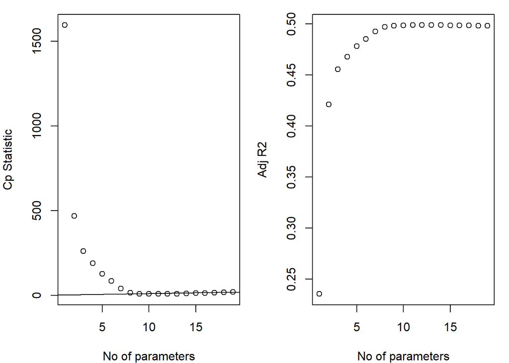

```r
# Plots for Cp Statistic and Adjusted R2
par(mar = c(4,4,1,1))
par(mfrow = c(1,2))

# Cp Statistic Plot
plot(x = 1:19, y = crit_sum$cp, xlab = "No of parameters", ylab = "Cp Statistic")
# abline - adds straight lines to a plot
abline(0,1)

# Adjusted R2 Plot
plot(x = 1:19, y = crit_sum$adjr2, xlab = "No of parameters", ylab = "Adj R2")
```

**Summary Table for Cp Statistic and Adjusted R2**

```r
# fit with all parameters
fit_multi = lm(target_death_rate ~ ., data = cancer_reg_tidy)

# best subset of variables for given number of parameters
best = function(model, ...) {

  subsets <- regsubsets(formula(model), nvmax = 18, model.frame(model), ...)
  subsets <- with(summary(subsets), cbind(p = as.numeric(rownames(which)), which, rss, rsq, adjr2, cp, bic))

  return(subsets)
}

# Select the 'best' model of all subsets for 8-predictor model
cp_r2_df = round(best(fit_multi, nbest = 1), digits = 3)
cp_r2_df
```

```
##     p (Intercept) incidence_rate med_income pop_est2015 study_per_cap
## 1   1           1              0          0           0             0
## 2   2           1              1          0           0             0
## 3   3           1              1          0           0             0
## 4   4           1              1          0           0             0
## 5   5           1              1          0           0             0
## 6   6           1              1          0           0             0
## 7   7           1              1          0           0             0
## 8   8           1              1          0           0             0
## 9   9           1              1          0           0             0
## 10 10           1              1          0           0             0
## 11 11           1              1          0           1             0
## 12 12           1              1          1           1             0
## 13 13           1              1          1           1             0
## 14 14           1              1          1           1             0
```

[output cut: 99 more lines]

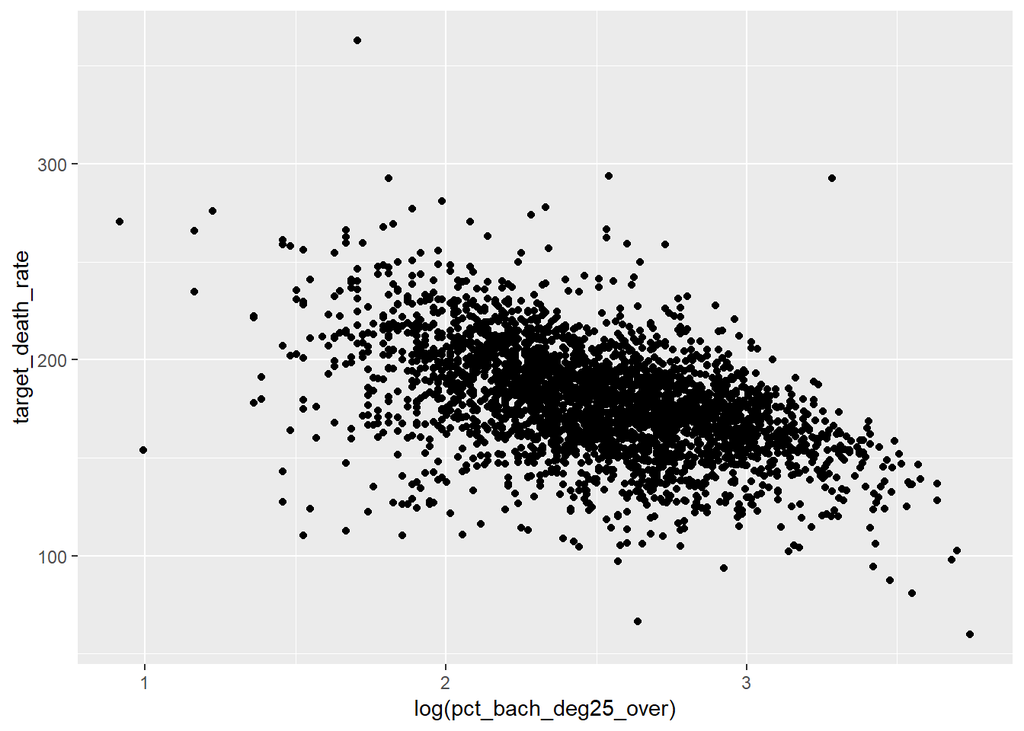

```r
# should take log for pct_bach_deg25_over variable
cancer_reg_tidy %>%
  ggplot(aes(x = log(pct_bach_deg25_over), y = target_death_rate)) +
  geom_point()
```